# Causal ML: Double ML for average treatment effects

Application notebook

Michael Knaus

02/23

Goals:

- Handcode Double ML for ATE using AIPW
- Implement it using the `causalDML` package

# Introducing the data

The Application Notebook builds on the dataset that is kindly provided in the `hdm` package. The data was used in [Chernozhukov and Hansen (2004)](https://direct.mit.edu/rest/article/86/3/735/57586/The-Effects-of-401-K-Participation-on-the-Wealth). Their paper investigates the effect of participation in the employer-sponsored 401(k) retirement savings plan (`p401`) on net assets (`net_tfa`). Since then the data was used to showcase many new methods. It is not the most comprehensive dataset with basically ten covariates/regressors/predictors:

- *age*: age
- *db*: defined benefit pension
- *educ*: education (in years)
- *fsize*: family size
- *hown*: home owner
- *inc*: income (in US $)
- *male*: male
- *marr*: married
- *pira*: participation in individual retirement account (IRA)
- *twoearn*: two earners

However, it is publicly available and the relatively few covariates ensure that the programs do not run too long.

```r
# To install the causalDML package uncomment the following two lines
# library(devtools)
# install_github(repo="MCKnaus/causalDML")

# Load the packages required for later
library(hdm)
library(tidyverse)
library(causalDML)
library(grf)
library(lmtest)
library(sandwich)


set.seed(1234) # for replicability
options(scipen = 10) # Switch off scientific notation

data(pension)
# Outcome
Y = pension$net_tfa
# Treatment
W = pension$p401
# Create main effects matrix
X = model.matrix(~ 0 + age + db + educ + fsize + hown + inc + male + marr + pira + twoearn, data = pension)
```

# Hand-coded Double ML for AIPW

To implement the AIPW we estimate the nuisance parameters $e(X)=E[W|X]$, $m(0,X)=E[Y|W=0,X]$ and $m(1,X)=E[Y|W=1,X]$ using random forest and plug the predictions into the pseudo outcome:
$$\tilde{Y}_{ATE} = \underbrace{\hat{m}(1,X) -
\hat{m}(0,X)}_{\text{outcome predictions}} + \underbrace{\frac{W (Y -
\hat{m}(1,X))}{\hat{e}(X)} - \frac{(1-W) (Y -
\hat{m}(0,X))}{1-\hat{e}(X)}}_{\text{weighted residuals}}$$

The theoretical results require that we predict the nuisance parameters out-of-sample. The easiest way to do this is two-fold cross-fitting:

- Split the sample in two random subsamples, S1 and S2
- Form prediction models in S1, use it to predict in S2
- Form prediction models in S2, use it to predict in S1
- Plug the prediction in the pseudo-outcome

```r
# 2-fold cross-fitting
n = length(Y)
m0hat = m1hat = ehat = rep(NA,n)
# Draw random indices for sample 1
index_s1 = sample(1:n,n/2)
# Create S1
x1 = X[index_s1,]
w1 = W[index_s1]
y1 = Y[index_s1]
# Create sample 2 with those not in S1
x2 = X[-index_s1,]
w2 = W[-index_s1]
y2 = Y[-index_s1]
# Model in S1, predict in S2
rf = regression_forest(x1,w1)
ehat[-index_s1] = predict(rf,newdata=x2)$predictions
rf = regression_forest(x1[w1==0,],y1[w1==0])
m0hat[-index_s1] = predict(rf,newdata=x2)$predictions
rf = regression_forest(x1[w1==1,],y1[w1==1])
m1hat[-index_s1] = predict(rf,newdata=x2)$predictions
# Model in S2, predict in S1
rf = regression_forest(x2,w2)
ehat[index_s1] = predict(rf,newdata=x1)$predictions
rf = regression_forest(x2[w2==0,],y2[w2==0])
m0hat[index_s1] = predict(rf,newdata=x1)$predictions
rf = regression_forest(x2[w2==1,],y2[w2==1])
m1hat[index_s1] = predict(rf,newdata=x1)$predictions
# Generate pseudo-outcome and take and test mean
pseudo_y =  m1hat - m0hat +
  W*(Y-m1hat) / ehat - (1-W)*(Y-m0hat) / (1-ehat)
```

Finally, run OLS with only a constant to get the effect estimate and inference (this is equivalent to running a t-test on the mean of the pseudo-outcome).

```r
summary(lm(pseudo_y ~ 1))
```

```
Call:
lm(formula = pseudo_y ~ 1)

Residuals:
     Min       1Q   Median       3Q      Max
-2635515   -13172    -2157    12260  3290639

Coefficients:
            Estimate Std. Error t value Pr(>|t|)
(Intercept)    11486       1160   9.899   <2e-16 ***
---
Signif. codes:  0 ‘***’ 0.001 ‘**’ 0.01 ‘*’ 0.05 ‘.’ 0.1 ‘ ’ 1

Residual standard error: 115500 on 9914 degrees of freedom
```

# Double ML for AIPW with `causalDML` package

2-fold cross-fitting is easy to implement but especially in small sample sizes, using only 50% of the data to estimate the nuisance parameters might lead to unstable predictions.

Thus, we use the `DML_aipw` function of the `causalDML` package to run 5-fold cross-fitting. For now, we focus again on honest random forest.

With 5-fold cross-fitting, we split the sample in 5 folds and use 4 folds (80% of the data) to predict the left out fold (20% of the data). We iterate such that every fold is left out once.

```r
# 5-fold cross-fitting with causalDML package
aipw = DML_aipw(Y,W,X,cf=5)
```

Let’s first have a look at the estimated average potential outcomes:

```r
summary(aipw$APO)
```

```
       APO       SE
0 14183.93 809.4144
1 25702.51 951.4991
```

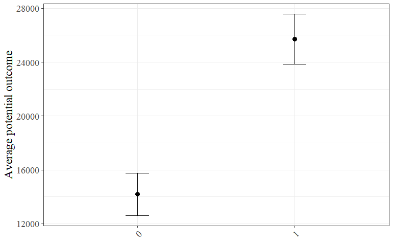

```r
plot(aipw$APO)
```

The average treatment effect is then just the difference between the two potential outcomes:

```r
summary(aipw$ATE)
```

```
          ATE      SE      t         p
1 - 0 11518.6  1166.1 9.8781 < 2.2e-16 ***
---
Signif. codes:  0 ‘***’ 0.001 ‘**’ 0.01 ‘*’ 0.05 ‘.’ 0.1 ‘ ’ 1
```

Finally, we can use the same nuisance parameters to estimate the ATT:

```r
APO_atet = APO_dml_atet(Y,aipw$APO$m_mat,aipw$APO$w_mat,aipw$APO$e_mat,aipw$APO$cf_mat)
ATET = ATE_dml(APO_atet)
summary(ATET)
```

```
         ATET      SE      t                   p
1 - 0 14792.6  1932.9 7.6532 0.00000000000002144 ***
---
Signif. codes:  0 ‘***’ 0.001 ‘**’ 0.01 ‘*’ 0.05 ‘.’ 0.1 ‘ ’ 1
```

We find that the ATT is roughly $3000 higher than the ATE:

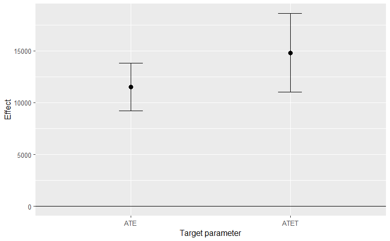

```r
# Collect the results
Effect = c(aipw$ATE$result[1],ATET$results[1])
se = c(aipw$ATE$result[2],ATET$results[2])
data.frame(Effect,se,
                Target = c("ATE","ATET"),
                cil = Effect - 1.96*se,
                ciu = Effect + 1.96*se)  %>%
  ggplot(aes(x=Target,y=Effect,ymin=cil,ymax=ciu)) + geom_point(size=2.5) + geom_errorbar(width=0.15)  +
  geom_hline(yintercept=0) + xlab("Target parameter")
```